# Ciclo financiero del Perú — versión en R

Réplica de la pipeline en Python y variante con las herramientas del asesor

Roberto Samaniego Salcedo · Asesor: Dr. Sergio Camiz

08/10/2026

# 1 Propósito y alcance

Este documento reproduce en R la pipeline de la tesis que está en los notebooks de Python, sobre **los mismos datos procesados** (`data/processed/`), y agrega una variante con las herramientas del asesor (paquetes `Rcamiz` y `AedeClahfac`). Tiene dos objetivos:

1. **Paridad.** Verificar que R y Python producen los mismos resultados cuando se usan las mismas decisiones metodológicas. Cada sección termina con una comparación contra los archivos de `data/results/` generados por Python.
2. **Variante del asesor.** Aplicar los métodos tal como los implementa el Dr. Camiz: HFC con `clahfac()`, EPCA con `aede()` (pesos gaussianos, reglas de signo y partición de Fisher con el índice de Calinski-Harabász) y una HFC evolutiva por ventanas.

| Sección | Python | R (réplica) | R (variante del asesor) |
| --- | --- | --- | --- |
| PCA y análisis paralelo de Horn | `07`, `08` | `pca()` de Rcamiz | — |
| Componentes en el tiempo (MM12) | `05b` | sí | — |
| HFC | — | — | `clahfac()` |
| EPCA | `06` | sí | `aede()` |
| HFC evolutiva | — | — | `clahfac()` por ventanas |
| Datación de regímenes | `09` | Fisher + regla de codo | Fisher + Calinski-Harabász |
| Autoencoders y LSTM | `08`, `09` | `torch` para R | — |

**Requisitos.** R ≥ 4.0 con `Rcamiz`, `AedeClahfac`, `dendextend` y `knitr`/`rmarkdown`. Los paquetes del asesor no se distribuyen en el repositorio. `AedeClahfac` incluye una rutina Fortran compilada para Linux (`x86_64-pc-linux-gnu`): en otro sistema operativo las secciones que la usan se omiten automáticamente. Las secciones de aprendizaje profundo requieren `torch` para R (`install.packages("torch"); torch::install_torch()`).

```r
suppressMessages({
  library(Rcamiz)
  library(dendextend)
})

# AedeClahfac contiene código compilado para Linux: se verifica que cargue
tiene_aede <- suppressWarnings(tryCatch({
  suppressMessages(library(AedeClahfac))
  TRUE
}, error = function(e) FALSE))

# torch para R: solo si está instalado y con libtorch disponible
tiene_torch <- requireNamespace("torch", quietly = TRUE) &&
  tryCatch(torch::torch_is_installed(), error = function(e) FALSE)
ejecutar_dl <- if (identical(params$ejecutar_dl, "auto")) tiene_torch else isTRUE(params$ejecutar_dl)

data.frame(
  componente = c("R", "Rcamiz", "AedeClahfac", "torch (AE/LSTM)"),
  estado = c(R.version.string,
             as.character(packageVersion("Rcamiz")),
             if (tiene_aede) as.character(packageVersion("AedeClahfac")) else "no disponible",
             if (ejecutar_dl) as.character(packageVersion("torch")) else "no disponible: se omite")
)
```

| componente | estado |
| --- | --- |
| R | R version 4.3.3 (2024-02-29) |
| Rcamiz | 0.4.2 |
| AedeClahfac | 1.2 |
| torch (AE/LSTM) | no disponible: se omite |

# 2 Datos y funciones comunes

```r
# Dataset mensual transformado: el mismo que usan 05b, 07, 08 y 09 en Python
df <- read.csv("data/processed/dataset_transformado_mensual.csv", row.names = 1,
               check.names = FALSE)
fechas <- as.Date(rownames(df))
nombres <- sub("_log_diff$|_diff$", "", colnames(df))
n <- nrow(df); p <- ncol(df)

# Controles: no se trabaja con datos incompletos
stopifnot(!anyNA(df))
calendario <- seq(min(fechas), max(fechas), by = "month")
if (length(calendario) != n || any(calendario != fechas)) {
  stop("El calendario mensual tiene huecos: revisar 04b antes de continuar")
}
cat(sprintf("%d meses x %d variables, %s a %s; calendario completo y sin faltantes\n",
            n, p, format(min(fechas), "%Y-%m"), format(max(fechas), "%Y-%m")))
```

```
## 227 meses x 17 variables, 2007-02 a 2025-12; calendario completo y sin faltantes
```

```r
# Episodios de referencia: solo para validación ex post (mismas fechas que modelos_dl.py)
episodios <- data.frame(
  nombre = c("Crisis financiera global", "Taper tantrum", "COVID-19"),
  inicio = as.Date(c("2008-09-01", "2013-05-01", "2020-03-01")),
  fin    = as.Date(c("2009-06-01", "2013-12-01", "2020-12-01"))
)
```

Las funciones siguientes son traducciones directas de `notebooks/modelos_dl.py`, para que las comparaciones con Python usen exactamente el mismo cálculo.

```r
# Estandarización con desviación poblacional (divisor n), igual que StandardScaler
estandarizar <- function(X) {
  X <- as.matrix(X)
  m <- colMeans(X)
  s <- sqrt(colMeans(sweep(X, 2, m)^2))
  sweep(sweep(X, 2, m), 2, s, "/")
}

# PCA por descomposición espectral de la matriz de correlación (divisor n)
# con la regla de signo de Rcamiz: domina la suma de cuadrados de los coeficientes positivos
pca_basico <- function(Z, d = ncol(Z)) {
  e <- eigen(crossprod(Z) / nrow(Z), symmetric = TRUE)
  V <- e$vectors[, 1:d, drop = FALSE]
  for (k in seq_len(d)) {
    if (sum(V[V[, k] < 0, k]^2) > sum(V[V[, k] > 0, k]^2)) V[, k] <- -V[, k]
  }
  list(valores = e$values, vectores = V, scores = Z %*% V)
}

# Análisis paralelo de Horn (1965): percentil 95 de autovalores con datos gaussianos
horn <- function(X, n_sim = 1000, percentil = 0.95, semilla = 42) {
  set.seed(semilla)
  obs <- eigen(cor(X), symmetric = TRUE, only.values = TRUE)$values
  sims <- t(replicate(n_sim, eigen(cor(matrix(rnorm(nrow(X) * ncol(X)), nrow(X))),
                                   symmetric = TRUE, only.values = TRUE)$values))
  umbral <- apply(sims, 2, quantile, probs = percentil)
  retener <- 0
  for (j in seq_along(obs)) if (obs[j] > umbral[j]) retener <- retener + 1 else break
  list(observados = obs, umbral = umbral, retener = retener)
}

# Coeficiente RV de Robert & Escoufier (1976) entre dos configuraciones de las mismas filas
coef_rv <- function(X, Y) {
  X <- scale(as.matrix(X), scale = FALSE); Y <- scale(as.matrix(Y), scale = FALSE)
  Sx <- tcrossprod(X); Sy <- tcrossprod(Y)
  sum(Sx * Sy) / sqrt(sum(Sx * Sx) * sum(Sy * Sy))
}

# Rotación ortogonal de Procrustes de Z hacia la referencia
procrustes <- function(Z, referencia) {
  Zc <- scale(Z, scale = FALSE); Rc <- scale(referencia, scale = FALSE)
  s <- svd(crossprod(Zc, Rc))
  Zc %*% (s$u %*% t(s$v))
}

# Partición óptima de Fisher (1958) de una serie ordenada en k segmentos contiguos,
# por programación dinámica exacta (traducción de particion_fisher)
particion_fisher <- function(Y, k_max = 8, tam_min = 6) {
  Y <- as.matrix(Y); n <- nrow(Y)
  S1 <- rbind(0, apply(Y, 2, cumsum))
  S2 <- c(0, cumsum(rowSums(Y^2)))
  sce <- function(i, j) {               # segmento de las filas i+1..j
    s <- S1[j + 1, ] - S1[i + 1, ]
    S2[j + 1] - S2[i + 1] - sum(s * s) / (j - i)
  }
  D <- matrix(Inf, k_max, n); B <- matrix(0L, k_max, n)
  for (j in tam_min:n) D[1, j] <- sce(0, j)
  for (k in 2:k_max) {
    if (k * tam_min > n) break
    for (j in (k * tam_min):n) {
      ini <- ((k - 1) * tam_min):(j - tam_min)
      costos <- vapply(ini, function(i) D[k - 1, i] + sce(i, j), numeric(1))
      D[k, j] <- min(costos); B[k, j] <- ini[which.min(costos)]
    }
  }
  res <- list()
  for (k in 1:k_max) {
    if (!is.finite(D[k, n])) next
    cortes <- integer(0); j <- n
    if (k > 1) for (kk in k:2) { i <- B[kk, j]; cortes <- c(i, cortes); j <- i }
    res[[as.character(k)]] <- list(sce = D[k, n], cortes = cortes)  # cortes: índice 0-based del inicio de segmento
  }
  res
}

# Datación como en 09: estandarizar, Fisher (k <= 10, segmentos >= 12 meses) y regla de codo
datar <- function(Y, k_max = 10, tam_min = 12, umbral = 0.10) {
  res <- particion_fisher(estandarizar(Y), k_max, tam_min)
  sce <- sapply(res, `[[`, "sce")
  reduccion <- c(-diff(sce) / head(sce, -1), NA)   # reducción relativa al pasar de k a k+1
  k_codo <- min(as.integer(names(sce))[which(reduccion < umbral)])
  # Variante del asesor: Calinski-Harabász con la misma fórmula de aede()
  # (grados de libertad k y n - k, como en el código del asesor)
  nk <- nrow(Y); ks <- as.integer(names(sce))
  ch <- ((sce[1] - sce) / ks) / (sce / (nk - ks)); ch[1] <- NA
  list(res = res, tabla = data.frame(k = ks, sce = sce, reduccion = reduccion, ch = ch),
       k_codo = k_codo, k_ch = ks[which.max(ch)])
}

# Segmentos (inicio, fin) a partir de los cortes de Fisher
segmentos <- function(cortes, fechas_serie) {
  bordes <- c(0, cortes, length(fechas_serie))
  data.frame(inicio = fechas_serie[head(bordes, -1) + 1], fin = fechas_serie[tail(bordes, -1)])
}

# Fecha del primer mes de cada régimen nuevo (como en las tablas de Python)
fechas_corte <- function(cortes, fechas_serie) format(fechas_serie[cortes + 1], "%Y-%m")
```

# 3 PCA con Rcamiz y análisis paralelo de Horn

```r
res_pca <- pca(df, st = TRUE, nd = p, r = 10)
vp <- res_pca$eigenvalues
round(head(vp, 6), 3)
```

```
##       eigen inertia cum.in
## Dim_1 3.956  23.273 23.273
## Dim_2 2.712  15.950 39.223
## Dim_3 1.896  11.152 50.375
## Dim_4 1.466   8.625 59.000
## Dim_5 1.033   6.077 65.077
## Dim_6 1.006   5.918 70.995
```

```r
Z <- estandarizar(df)
h <- horn(Z, n_sim = 1000)
tabla_horn <- data.frame(componente = paste0("PC", 1:6), autovalor = round(h$observados[1:6], 3),
                         umbral_p95 = round(h$umbral[1:6], 3))
tabla_horn
```

| componente | autovalor | umbral_p95 |
| --- | --- | --- |
| PC1 | 3.956 | 1.615 |
| PC2 | 2.712 | 1.469 |
| PC3 | 1.896 | 1.378 |
| PC4 | 1.466 | 1.302 |
| PC5 | 1.033 | 1.238 |
| PC6 | 1.006 | 1.180 |

```r
cat("Componentes retenidos por Horn:", h$retener, "\n")
```

```
## Componentes retenidos por Horn: 4
```

```r
# Paridad con Python: inercia de 08 (anclaje lineal) y Horn de 08
anclaje_py <- read.csv("data/results/08_ae_anclaje_lineal.csv")
horn_py <- read.csv("data/results/08_ae_horn.csv", row.names = 1)
d_horn_py <- sum(cumprod(horn_py$autovalor_observado > horn_py$umbral_aleatorio_p95))
paridad <- data.frame(
  seccion = c("PCA: inercia acumulada d=1..5 (dif. máx., puntos %)",
              "Horn: componentes retenidos (R / Python)"),
  resultado = c(signif(max(abs(vp[1:5, "cum.in"] - anclaje_py$inercia_pca_.)), 3),
                paste(h$retener, "/", d_horn_py))
)
paridad
```

| seccion | resultado |
| --- | --- |
| PCA: inercia acumulada d=1..5 (dif. máx., puntos %) | 4.01e-11 |
| Horn: componentes retenidos (R / Python) | 4 / 4 |

# 4 Componentes principales en el tiempo (réplica de 05b)

```r
N_COMP <- 3
pc <- pca_basico(Z, N_COMP)
scores <- pc$scores
colnames(scores) <- paste0("PC", 1:N_COMP)

# Medias móviles centradas y causales, como pandas rolling(w, center=True) y rolling(w)
mm_centrada <- function(x, w) {
  r <- stats::filter(x, rep(1 / w, w), sides = 2)
  # Con ventana par, pandas ubica la media una posición más tarde que stats::filter
  if (w %% 2 == 0) r <- c(NA, r[-length(r)])
  as.numeric(r)
}
mm_causal <- function(x, w) as.numeric(stats::filter(x, rep(1 / w, w), sides = 1))

s05b <- read.csv("data/results/05b_scores_suavizados.csv", row.names = 1)
dif <- sapply(1:N_COMP, function(k) c(
  scores = max(abs(scores[, k] - s05b[[paste0("PC", k)]])),
  mm12_centrada = max(abs(mm_centrada(scores[, k], 12) - s05b[[paste0("PC", k, "_mm12_centrada")]]), na.rm = TRUE),
  mm12_causal = max(abs(mm_causal(scores[, k], 12) - s05b[[paste0("PC", k, "_mm12_causal")]]), na.rm = TRUE)))
colnames(dif) <- colnames(scores)
signif(dif, 3)
```

```
##                    PC1      PC2      PC3
## scores        1.78e-14 1.69e-14 1.24e-14
## mm12_centrada 5.00e-15 6.00e-15 4.22e-15
## mm12_causal   5.00e-15 6.00e-15 4.22e-15
```

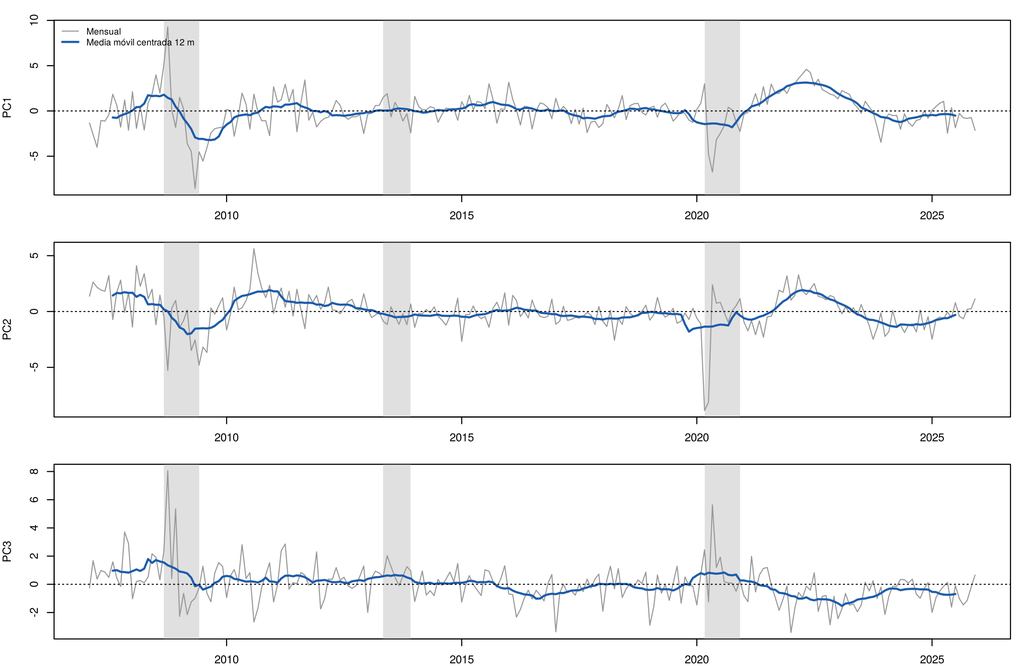

```r
sombrear <- function() {
  for (i in seq_len(nrow(episodios))) {
    rect(episodios$inicio[i], par("usr")[3], episodios$fin[i], par("usr")[4],
         col = adjustcolor("grey70", 0.4), border = NA)
  }
}
op <- par(mfrow = c(N_COMP, 1), mar = c(2, 4, 1.5, 1))
for (k in 1:N_COMP) {
  plot(fechas, scores[, k], type = "n", ylab = colnames(scores)[k], xlab = "")
  sombrear()
  lines(fechas, scores[, k], col = "grey60")
  lines(fechas, mm_centrada(scores[, k], 12), col = "#1c5cab", lwd = 2)
  abline(h = 0, lty = 3)
  if (k == 1) legend("topleft", c("Mensual", "Media móvil centrada 12 m"),
                     col = c("grey60", "#1c5cab"), lwd = c(1, 2), bty = "n", cex = 0.8)
}
```

```r
par(op)
```

# 5 Clasificación Factorial Jerárquica (variante del asesor)

La HFC (`clahfac()`) agrupa las **variables** de forma jerárquica: en cada nodo se unen los dos grupos cuya fusión conserva la mayor parte de la inercia en el primer factor del grupo resultante. El índice del nodo mide la inercia que se pierde al representar el grupo por un solo factor.

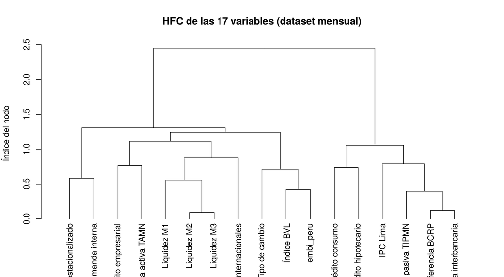

```r
df_hfc <- df
colnames(df_hfc) <- nombres
# clahfac imprime los cambios de signo de los factores de cada nodo: se silencia esa salida
invisible(capture.output(hfc <- clahfac(df_hfc, out = TRUE)))
plot(as.dendrogram(hfc$hier), main = "HFC de las 17 variables (dataset mensual)",
     ylab = "Índice del nodo")
```

```r
jerarquia <- as.data.frame(hfc$hierar[, c("ngr", "N1", "N2", "Num", "Eigenv", "Index",
                                          "Glob_%1", "Cum_%2")])
round(jerarquia, 3)
```

|  | ngr | N1 | N2 | Num | Eigenv | Index | Glob_%1 | Cum_%2 |
| --- | --- | --- | --- | --- | --- | --- | --- | --- |
| 18 | 16 | 11 | 12 | 2 | 1.907 | 0.093 | 11.220 | 0.545 |
| 19 | 15 | 15 | 16 | 2 | 1.878 | 0.122 | 11.047 | 1.262 |
| 20 | 14 | 14 | 19 | 3 | 2.484 | 0.394 | 14.611 | 3.581 |
| 21 | 13 | 5 | 17 | 2 | 1.580 | 0.420 | 9.296 | 6.049 |
| 22 | 12 | 10 | 18 | 3 | 2.349 | 0.558 | 13.820 | 9.332 |
| 23 | 11 | 7 | 8 | 2 | 1.417 | 0.583 | 8.333 | 12.763 |
| 24 | 10 | 4 | 21 | 3 | 1.869 | 0.712 | 10.991 | 16.950 |
| 25 | 9 | 2 | 3 | 2 | 1.264 | 0.736 | 7.436 | 21.279 |
| 26 | 8 | 1 | 13 | 2 | 1.235 | 0.765 | 7.266 | 25.778 |
| 27 | 7 | 6 | 20 | 4 | 2.695 | 0.788 | 15.855 | 30.416 |
| 28 | 6 | 22 | 9 | 4 | 2.476 | 0.873 | 14.565 | 35.554 |
| 29 | 5 | 25 | 27 | 6 | 2.902 | 1.057 | 17.073 | 41.771 |
| 30 | 4 | 26 | 28 | 6 | 2.597 | 1.114 | 15.277 | 48.325 |
| 31 | 3 | 30 | 24 | 9 | 3.225 | 1.241 | 18.969 | 55.624 |
| 32 | 2 | 23 | 31 | 11 | 3.336 | 1.305 | 19.626 | 63.300 |
| 33 | 1 | 32 | 29 | 17 | 3.789 | 2.450 | 22.288 | 77.712 |

```r
round(hfc$inertia, 2)
```

```
##         Hierarchy Repr_Var Total
## Inertia     13.21     3.79    17
## Percent     77.71    22.29   100
```

El número de grupos es una decisión de interpretación. Se muestran las particiones que resultan de cortar los 1, 2 y 3 nodos superiores (`clahpart()`), junto con el índice de esos nodos: un salto grande del índice indica que esa fusión une grupos poco afines.

```r
indices_superiores <- rev(tail(hfc$hierar[, "Index"], 4))
data.frame(nodo = paste0("Nodo superior ", 1:4), indice = round(indices_superiores, 3))
```

|  | nodo | indice |
| --- | --- | --- |
| 33 | Nodo superior 1 | 2.450 |
| 32 | Nodo superior 2 | 1.305 |
| 31 | Nodo superior 3 | 1.241 |
| 30 | Nodo superior 4 | 1.114 |

```r
particiones <- lapply(1:3, function(k) {
  invisible(capture.output(pc <- clahpart(hfc, noeud = k)))
  grupos <- tapply(pc$itemclas$label, pc$itemclas$class, paste, collapse = ", ")
  data.frame(corte = paste(k, "nodo(s) superior(es)"), grupo = names(grupos),
             variables = as.character(grupos))
})
do.call(rbind, particiones)
```

| corte | grupo | variables |
| --- | --- | --- |
| 1 nodo(s) superior(es) | 29 | Crédito consumo, Crédito hipotecario, IPC Lima, Tasa pasiva TIPMN, Tasa referencia BCRP, Tasa interbancaria |
| 1 nodo(s) superior(es) | 32 | PBI desestacionalizado, Demanda interna, Tipo de cambio, Crédito empresarial, Tasa activa TAMN, Reservas internacionales, Índice BVL, embi_peru, Liquidez M1, Liquidez M2, Liquidez M3 |
| 2 nodo(s) superior(es) | 23 | PBI desestacionalizado, Demanda interna |
| 2 nodo(s) superior(es) | 29 | Crédito consumo, Crédito hipotecario, IPC Lima, Tasa pasiva TIPMN, Tasa referencia BCRP, Tasa interbancaria |
| 2 nodo(s) superior(es) | 31 | Tipo de cambio, Crédito empresarial, Tasa activa TAMN, Reservas internacionales, Índice BVL, embi_peru, Liquidez M1, Liquidez M2, Liquidez M3 |
| 3 nodo(s) superior(es) | 23 | PBI desestacionalizado, Demanda interna |
| 3 nodo(s) superior(es) | 24 | Tipo de cambio, Índice BVL, embi_peru |
| 3 nodo(s) superior(es) | 29 | Crédito consumo, Crédito hipotecario, IPC Lima, Tasa pasiva TIPMN, Tasa referencia BCRP, Tasa interbancaria |
| 3 nodo(s) superior(es) | 30 | Crédito empresarial, Tasa activa TAMN, Reservas internacionales, Liquidez M1, Liquidez M2, Liquidez M3 |

# 6 EPCA

## 6.1 Réplica de `06` (ventana de 60 meses, paso de 3 meses)

```r
df_std <- read.csv("data/processed/dataset_estandarizado_mensual.csv", row.names = 1,
                   check.names = FALSE)
fechas_std <- as.Date(rownames(df_std))
VENTANA <- 60; PASO <- 3

inicios <- seq(1, nrow(df_std) - VENTANA + 1, by = PASO)
epca <- lapply(inicios, function(i) {
  Zv <- estandarizar(df_std[i:(i + VENTANA - 1), ])
  e <- eigen(crossprod(Zv) / VENTANA, symmetric = TRUE)
  list(fecha = fechas_std[i + VENTANA %/% 2], var = e$values / sum(e$values),
       carga1 = e$vectors[, 1])
})
fechas_epca <- do.call(c, lapply(epca, `[[`, "fecha"))
cargas_pc1 <- t(sapply(epca, `[[`, "carga1"))

# Alineación de signo con la ventana anterior (como en 06)
for (i in 2:nrow(cargas_pc1)) {
  if (cor(cargas_pc1[i, ], cargas_pc1[i - 1, ]) < 0) cargas_pc1[i, ] <- -cargas_pc1[i, ]
}
estabilidad <- sapply(2:nrow(cargas_pc1), function(i) cor(cargas_pc1[i, ], cargas_pc1[i - 1, ]))
umbral_estab <- mean(estabilidad) - sqrt(mean((estabilidad - mean(estabilidad))^2))
transiciones_r <- format(fechas_epca[-1][estabilidad < umbral_estab], "%Y-%m")

trans_py <- format(as.Date(read.csv("data/results/06_epca_transiciones_detectadas.csv")[[1]]), "%Y-%m")
var_py <- read.csv("data/results/06_epca_varianza_explicada.csv")
data.frame(
  control = c("Ventanas (R / Python)", "Varianza PC1: dif. máx. (puntos %)",
              "Transiciones R", "Transiciones Python"),
  resultado = c(paste(length(epca), "/", nrow(var_py)),
                signif(max(abs(100 * sapply(epca, function(e) e$var[1]) - var_py$var_pc1)), 3),
                paste(transiciones_r, collapse = ", "), paste(trans_py, collapse = ", "))
)
```

| control | resultado |
| --- | --- |
| Ventanas (R / Python) | 56 / 56 |
| Varianza PC1: dif. máx. (puntos %) | 9.24e-14 |
| Transiciones R | 2013-05, 2017-11, 2018-02 |
| Transiciones Python | 2013-05, 2017-11, 2018-02 |

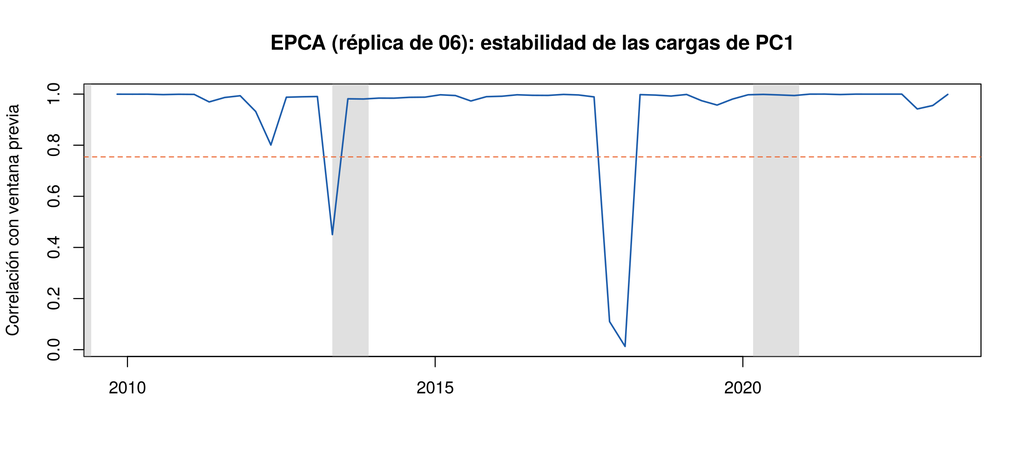

```r
plot(fechas_epca[-1], estabilidad, type = "n", xlab = "", ylab = "Correlación con ventana previa",
     main = "EPCA (réplica de 06): estabilidad de las cargas de PC1")
sombrear()
lines(fechas_epca[-1], estabilidad, col = "#1c5cab", lwd = 1.5)
abline(h = umbral_estab, col = "#eb6834", lty = 2)
```

## 6.2 Variante del asesor: `aede()`

`aede()` usa todas las ventanas (paso de un mes), dos reglas de signo (la determinística de Rcamiz y la de continuidad con la ventana anterior) y segmenta la serie del **primer valor propio** con el algoritmo de Fisher, informando el índice de Calinski-Harabász para cada número de clases. Se corre con pesos uniformes (`nsd = 0`, comparable con la réplica) y con pesos gaussianos (`nsd = 3`, valor por defecto de `claede`).

```r
correr_aede <- function(nsd) {
  a <- aede(serie = as.matrix(df), ndim = 3, nw = VENTANA, nsd = nsd, maxcl = 10)
  part <- a$cutpoints$part
  fechas_v <- as.Date(rownames(a$eigenvalues))
  k_ch <- which.max(part[, 3])                 # columna Calinski-Harabász
  limites <- part[k_ch, grep("^v_", colnames(part))]
  limites <- limites[limites > 0 & limites < nrow(a$eigenvalues)]
  list(a = a, part = part, fechas = fechas_v, k_ch = k_ch,
       cortes = format(fechas_v[limites + 1], "%Y-%m"))
}
aede_unif <- correr_aede(0)
aede_gaus <- correr_aede(3)

round(aede_unif$part[, 1:3], 2)
```

```
##        n Within ssq Calinski-Harabasz
##  [1,]  1     126.86              0.00
##  [2,]  2      48.97            132.01
##  [3,]  3      24.33            231.73
##  [4,]  4       9.48            507.89
##  [5,]  5       6.63            591.40
##  [6,]  6       5.24            627.25
##  [7,]  7       3.54            800.77
##  [8,]  8       3.10            797.52
##  [9,]  9       2.47            888.62
## [10,] 10       2.08            946.87
```

```r
data.frame(pesos = c("uniformes (nsd = 0)", "gaussianos (nsd = 3)"),
           k_calinski_harabasz = c(aede_unif$k_ch, aede_gaus$k_ch),
           inicio_de_cada_clase = c(paste(aede_unif$cortes, collapse = ", "),
                                    paste(aede_gaus$cortes, collapse = ", ")))
```

| pesos | k_calinski_harabasz | inicio_de_cada_clase |
| --- | --- | --- |
| uniformes (nsd = 0) | 10 | 2010-08, 2011-05, 2011-12, 2013-11, 2017-10, 2019-11, 2020-10, 2022-10, 2023-01 |
| gaussianos (nsd = 3) | 10 | 2010-11, 2011-11, 2013-11, 2016-09, 2018-05, 2018-12, 2019-12, 2020-09, 2022-02 |

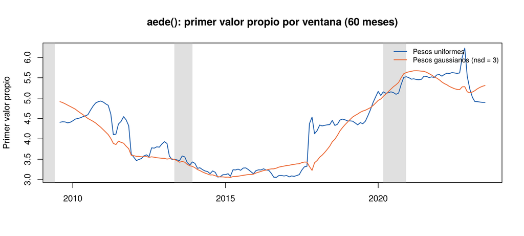

```r
plot(aede_unif$fechas, aede_unif$a$eigenvalues[, 1], type = "n", xlab = "",
     ylab = "Primer valor propio", main = "aede(): primer valor propio por ventana (60 meses)")
sombrear()
lines(aede_unif$fechas, aede_unif$a$eigenvalues[, 1], col = "#1c5cab", lwd = 1.5)
lines(aede_gaus$fechas, aede_gaus$a$eigenvalues[, 1], col = "#eb6834", lwd = 1.5)
legend("topright", c("Pesos uniformes", "Pesos gaussianos (nsd = 3)"),
       col = c("#1c5cab", "#eb6834"), lwd = 1.5, bty = "n", cex = 0.8)
```

# 7 HFC evolutiva (exploratoria)

Se aplica `clahfac()` en cada ventana de la EPCA (60 meses, paso 3) y se mide cuánto cambia la jerarquía de variables entre ventanas consecutivas con la **correlación cofenética** entre dendrogramas. Una caída indica que la estructura de agrupamiento de las variables se reconfigura. Sigue la lógica de `claede` (Camiz, 2025), aplicada aquí con la función del paquete.

```r
inicios_h <- seq(1, n - VENTANA + 1, by = PASO)
dendros <- lapply(inicios_h, function(i) {
  v <- df_hfc[i:(i + VENTANA - 1), ]
  invisible(capture.output(r <- clahfac(v, out = TRUE)))
  r$hier
})
fechas_ehfc <- fechas[inicios_h + VENTANA %/% 2]
cofen <- sapply(2:length(dendros), function(i)
  cor_cophenetic(as.dendrogram(dendros[[i]]), as.dendrogram(dendros[[i - 1]])))
umbral_cof <- mean(cofen) - sd(cofen)
cambios_ehfc <- format(fechas_ehfc[-1][cofen < umbral_cof], "%Y-%m")
cat("Reconfiguraciones de la jerarquía (correlación cofenética < media - 1 d.e.):\n",
    paste(cambios_ehfc, collapse = ", "), "\n")
```

```
## Reconfiguraciones de la jerarquía (correlación cofenética < media - 1 d.e.):
##  2010-11, 2011-02, 2011-05, 2011-08, 2012-02, 2015-08, 2017-11, 2019-05, 2019-08, 2019-11
```

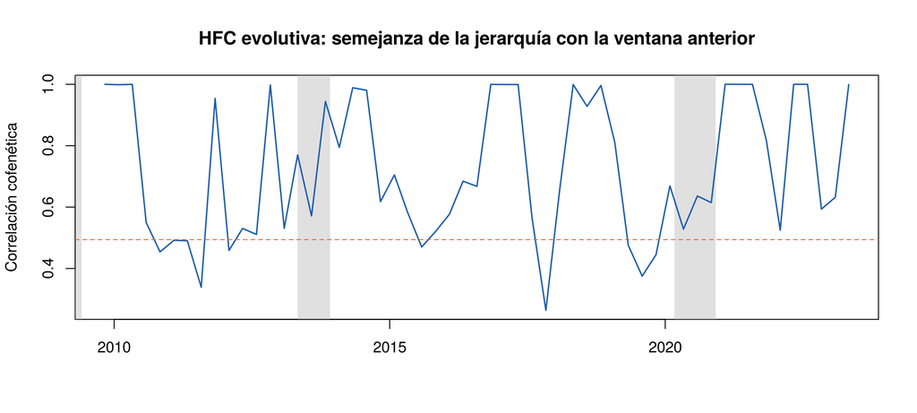

```r
plot(fechas_ehfc[-1], cofen, type = "n", xlab = "", ylab = "Correlación cofenética",
     main = "HFC evolutiva: semejanza de la jerarquía con la ventana anterior")
sombrear()
lines(fechas_ehfc[-1], cofen, col = "#1c5cab", lwd = 1.5)
abline(h = umbral_cof, col = "#eb6834", lty = 2)
```

# 8 Datación de regímenes (réplica de 09 y variante del asesor)

Como en `09`, se segmentan los scores del PCA (d = 3) suavizados con media móvil causal de 12 meses, con la partición de Fisher (segmentos de al menos 12 meses, hasta 10 regímenes). El número de regímenes se elige con la **regla de codo** de Python y, como variante, con el **índice de Calinski-Harabász** que usa `aede()`.

```r
L <- 12
mm12 <- apply(scores, 2, mm_causal, w = L)[L:n, ]
fechas_z <- fechas[L:n]
dat <- datar(mm12)
dat$tabla$sce <- round(dat$tabla$sce, 2)
dat$tabla$reduccion <- round(dat$tabla$reduccion, 3)
dat$tabla$ch <- round(dat$tabla$ch, 1)
dat$tabla
```

| k | sce | reduccion | ch |
| --- | --- | --- | --- |
| 1 | 648.00 | 0.182 | NA |
| 2 | 530.27 | 0.243 | 23.8 |
| 3 | 401.42 | 0.187 | 43.6 |
| 4 | 326.28 | 0.199 | 52.3 |
| 5 | 261.39 | 0.245 | 62.4 |
| 6 | 197.33 | 0.138 | 79.9 |
| 7 | 170.09 | 0.122 | 83.9 |
| 8 | 149.42 | 0.093 | 86.8 |
| 9 | 135.56 | 0.064 | 86.9 |
| 10 | 126.86 | NA | 84.6 |

```r
cat("k por regla de codo:", dat$k_codo, "| k por Calinski-Harabász:", dat$k_ch, "\n")
```

```
## k por regla de codo: 8 | k por Calinski-Harabász: 9
```

```r
cortes_codo <- fechas_corte(dat$res[[as.character(dat$k_codo)]]$cortes, fechas_z)
cortes_ch <- fechas_corte(dat$res[[as.character(dat$k_ch)]]$cortes, fechas_z)
reg_py <- read.csv("data/results/09_regimenes_pca.csv")
data.frame(
  datacion = c("R: regla de codo", "Python (09): regla de codo", "R: Calinski-Harabász"),
  k = c(dat$k_codo, nrow(reg_py), dat$k_ch),
  inicio_de_cada_regimen = c(paste(cortes_codo, collapse = ", "),
                             paste(reg_py$inicio[-1], collapse = ", "),
                             paste(cortes_ch, collapse = ", "))
)
```

| datacion | k | inicio_de_cada_regimen |
| --- | --- | --- |
| R: regla de codo | 8 | 2009-06, 2010-07, 2013-03, 2016-04, 2020-03, 2021-12, 2023-11 |
| Python (09): regla de codo | 8 | 2009-06, 2010-07, 2013-03, 2016-04, 2020-03, 2021-12, 2023-11 |
| R: Calinski-Harabász | 9 | 2009-06, 2010-07, 2013-03, 2016-04, 2020-04, 2021-04, 2022-04, 2023-11 |

```r
# Clasificación de fases como en 09: componente de crédito y regla (umbral 0.25, 18 meses)
cols_credito <- grep("^Cr.*dito", colnames(df))   # Crédito empresarial, consumo e hipotecario
stopifnot(length(cols_credito) == 3)
comp_credito <- rowMeans(estandarizar(df[, cols_credito]))
clasificar <- function(seg, umbral = 0.25, dur_min = 18) {
  do.call(rbind, lapply(seq_len(nrow(seg)), function(i) {
    sel <- fechas >= seg$inicio[i] & fechas <= seg$fin[i]
    m <- mean(comp_credito[sel]); dur <- sum(sel)
    fase <- if (dur < dur_min || abs(m) <= umbral) "Transición" else if (m > 0) "Expansión" else "Contracción"
    epi <- episodios$nombre[episodios$inicio <= seg$fin[i] & episodios$fin >= seg$inicio[i]]
    data.frame(inicio = format(seg$inicio[i], "%Y-%m"), fin = format(seg$fin[i], "%Y-%m"),
               meses = dur, componente_credito_medio = round(m, 2), fase = fase,
               episodios = paste(epi, collapse = ", "))
  }))
}
fases_codo <- clasificar(segmentos(dat$res[[as.character(dat$k_codo)]]$cortes, fechas_z))
fases_codo
```

| inicio | fin | meses | componente_credito_medio | fase | episodios |
| --- | --- | --- | --- | --- | --- |
| 2008-01 | 2009-05 | 17 | 0.66 | Transición | Crisis financiera global |
| 2009-06 | 2010-06 | 13 | 0.22 | Transición | Crisis financiera global |
| 2010-07 | 2013-02 | 32 | 0.57 | Expansión |  |
| 2013-03 | 2016-03 | 37 | -0.07 | Transición | Taper tantrum |
| 2016-04 | 2020-02 | 47 | -0.24 | Transición |  |
| 2020-03 | 2021-11 | 21 | -0.49 | Contracción | COVID-19 |
| 2021-12 | 2023-10 | 23 | -0.31 | Contracción |  |
| 2023-11 | 2025-12 | 26 | -0.52 | Contracción |  |

# 9 Autoencoders y LSTM con `torch` para R

> **Sección omitida en esta ejecución:** `torch` para R no está instalado en este equipo. Para ejecutarla: `install.packages("torch")` y luego `torch::install_torch()`.

Traducción a `torch` para R de `notebooks/modelos_dl.py`: autoencoder de pesos atados (lineal y no lineal) y LSTM-Autoencoder secuencia a secuencia con reconstrucción en orden inverso. Se replican el anclaje lineal (Proposición 1), la validación por bloques y la datación con el LSTM-AE. Los resultados de redes neuronales no coinciden número a número con Python, porque los generadores aleatorios de ambos lenguajes difieren: la paridad se evalúa sobre las conclusiones (MSE, RV y cortes), no sobre los pesos.

```r
library(torch)

fijar_semillas <- function(s) { set.seed(s); torch_manual_seed(s) }
a_tensor <- function(X) torch_tensor(X, dtype = torch_float())

# Autoencoder de pesos atados: dims = c(p, d) (una capa) o c(p, h, d) (dos capas)
autoencoder_atado <- nn_module(
  "AutoencoderAtado",
  initialize = function(dims, activacion = "tanh", dropout = 0) {
    self$n_capas <- length(dims) - 1
    self$activacion <- activacion
    self$W1 <- nn_parameter(nn_init_xavier_uniform_(torch_empty(dims[2], dims[1])))
    self$b_enc1 <- nn_parameter(torch_zeros(dims[2]))
    self$b_dec1 <- nn_parameter(torch_zeros(dims[1]))
    if (self$n_capas == 2) {
      self$W2 <- nn_parameter(nn_init_xavier_uniform_(torch_empty(dims[3], dims[2])))
      self$b_enc2 <- nn_parameter(torch_zeros(dims[3]))
      self$b_dec2 <- nn_parameter(torch_zeros(dims[2]))
    }
    self$drop <- nn_dropout(dropout)
  },
  act = function(h) if (self$activacion == "tanh") torch_tanh(h) else h,
  codificar = function(x) {
    h <- torch_matmul(x, self$W1$t()) + self$b_enc1
    if (self$n_capas == 2) {
      h <- self$drop(self$act(h))
      h <- torch_matmul(h, self$W2$t()) + self$b_enc2   # cuello de botella lineal
    }
    h
  },
  decodificar = function(z) {
    h <- z
    if (self$n_capas == 2) {
      h <- self$drop(self$act(torch_matmul(h, self$W2) + self$b_dec2))
    }
    torch_matmul(h, self$W1) + self$b_dec1
  },
  forward = function(x) self$decodificar(self$codificar(x))
)

# LSTM-Autoencoder (Srivastava, Mansimov & Salakhutdinov, 2015)
lstm_autoencoder <- nn_module(
  "LSTMAutoencoder",
  initialize = function(n_vars, dim_oculta = 16, dim_latente = 3, dropout = 0) {
    self$enc <- nn_lstm(n_vars, dim_oculta, batch_first = TRUE)
    self$a_latente <- nn_linear(dim_oculta, dim_latente)
    self$desde_latente <- nn_linear(dim_latente, dim_oculta)
    self$dec <- nn_lstm(dim_oculta, dim_oculta, batch_first = TRUE)
    self$salida <- nn_linear(dim_oculta, n_vars)
    self$drop <- nn_dropout(dropout)
  },
  codificar = function(x) {
    h <- self$enc(x)[[2]][[1]]                 # estado oculto final: (capas, lote, oculta)
    self$a_latente(self$drop(h[h$size(1), , ]))
  },
  decodificar = function(z, L) {
    h0 <- torch_tanh(self$desde_latente(z))
    entrada <- h0$unsqueeze(2)$expand(c(-1, L, -1))   # decodificador no condicionado
    self$salida(self$drop(self$dec(entrada)[[1]]))
  },
  forward = function(x) {
    rec_invertida <- self$decodificar(self$codificar(x), x$size(2))
    torch_flip(rec_invertida, dims = 2)       # se devuelve en orden cronológico
  }
)

# Ventanas deslizantes (n - L + 1, L, p); la ventana k se fecha en su último mes
crear_ventanas <- function(X, L) {
  m <- nrow(X) - L + 1
  W <- array(0, dim = c(m, L, ncol(X)))
  for (i in seq_len(m)) W[i, , ] <- X[i:(i + L - 1), ]
  W
}

# Índices de la primera dimensión de un tensor 2D o 3D
filas <- function(t, idx) if (t$dim() == 2) t[idx, ] else t[idx, , ]

# Entrenamiento con Adam, ruido de entrada (denoising) y parada temprana
entrenar <- function(modelo, X_ent, X_val = NULL, epocas = 2000, lr = 1e-2,
                     weight_decay = 1e-4, ruido = 0, paciencia = 150, semilla = 42) {
  fijar_semillas(semilla)
  X_ent <- a_tensor(X_ent); if (!is.null(X_val)) X_val <- a_tensor(X_val)
  opt <- optim_adam(modelo$parameters, lr = lr, weight_decay = weight_decay)
  mejor <- Inf; mejor_estado <- NULL; sin_mejora <- 0
  for (epoca in seq_len(epocas)) {
    modelo$train()
    lote <- filas(X_ent, sample(X_ent$size(1)))
    entrada <- if (ruido > 0) lote + ruido * torch_randn_like(lote) else lote
    opt$zero_grad()
    perdida <- nnf_mse_loss(modelo(entrada), lote)
    perdida$backward(); opt$step()
    modelo$eval()
    monitor <- with_no_grad({
      ref <- if (is.null(X_val)) X_ent else X_val
      nnf_mse_loss(modelo(ref), ref)$item()
    })
    if (monitor < mejor - 1e-7) {
      mejor <- monitor; sin_mejora <- 0
      mejor_estado <- lapply(modelo$state_dict(), function(t) t$clone())
    } else {
      sin_mejora <- sin_mejora + 1
      if (sin_mejora >= paciencia) break
    }
  }
  modelo$load_state_dict(mejor_estado); modelo$eval()
  invisible(mejor)
}

# Error de reconstrucción por observación (último paso de la ventana en el LSTM-AE)
error_reconstruccion <- function(modelo, X) {
  modelo$eval()
  with_no_grad({
    Xt <- a_tensor(X)
    E <- (modelo(Xt) - Xt)^2
    if (E$dim() == 3) E <- E[, E$size(2), ]
    as.numeric(as_array(E$mean(dim = 2)))
  })
}

codigos <- function(modelo, X) {
  modelo$eval(); with_no_grad(as_array(modelo$codificar(a_tensor(X))))
}
```

## 9.1 Anclaje lineal (Proposición 1)

```r
anclaje_r <- do.call(rbind, lapply(1:5, function(d) {
  ae <- autoencoder_atado(c(p, d), activacion = "lineal")
  mse_ae <- entrenar(ae, Z, epocas = 6000, lr = 1e-2, weight_decay = 0, paciencia = 400, semilla = d)
  pc_d <- pca_basico(Z, d)
  mse_pca <- mean((Z - pc_d$scores %*% t(pc_d$vectores))^2)
  W <- t(as_array(ae$W1$detach()))
  qa <- qr.Q(qr(W)); qb <- qr.Q(qr(pc_d$vectores))
  angulo <- max(acos(pmin(1, svd(crossprod(qa, qb))$d)) * 180 / pi)
  data.frame(d = d, mse_ae_lineal = mse_ae, mse_pca = mse_pca, angulo_max_grados = angulo)
}))
anclaje_r$mse_pca_python <- anclaje_py$mse_pca
signif(anclaje_r, 5)
```

## 9.2 Validación por bloques: PCA frente al AE no lineal

```r
cv_bloques <- function(Xcrudo, d, n_bloques = 5, semillas = 0:2) {
  bloques <- split(seq_len(nrow(Xcrudo)), cut(seq_len(nrow(Xcrudo)), n_bloques, labels = FALSE))
  r <- sapply(bloques, function(prueba) {
    ent <- setdiff(seq_len(nrow(Xcrudo)), prueba)
    m <- colMeans(Xcrudo[ent, ]); s <- sqrt(colMeans(sweep(Xcrudo[ent, ], 2, m)^2))
    Xe <- sweep(sweep(Xcrudo[ent, ], 2, m), 2, s, "/")
    Xp <- sweep(sweep(Xcrudo[prueba, ], 2, m), 2, s, "/")
    V <- pca_basico(Xe, d)$vectores
    mse_pca <- mean((Xp - Xp %*% V %*% t(V))^2)
    mse_ae <- mean(sapply(semillas, function(sm) {
      fijar_semillas(sm)
      ae <- autoencoder_atado(c(p, 8, d), activacion = "tanh", dropout = 0.10)
      corte <- floor(nrow(Xe) * 0.85)
      entrenar(ae, Xe[1:corte, ], Xe[(corte + 1):nrow(Xe), ], epocas = 3000, lr = 5e-3,
               weight_decay = 1e-3, ruido = 0.10, paciencia = 200, semilla = sm)
      mean(error_reconstruccion(ae, Xp))
    }))
    c(mse_pca, mse_ae)
  })
  rowMeans(r)
}
cv_r <- t(sapply(1:5, function(d) cv_bloques(as.matrix(df), d)))
cv_r <- data.frame(d = 1:5, mse_pca = cv_r[, 1], mse_ae_tanh = cv_r[, 2])
cv_r$mejora_ae_vs_pca_pct <- 100 * (cv_r$mse_pca - cv_r$mse_ae_tanh) / cv_r$mse_pca
cv_py <- read.csv("data/results/08_ae_cv_bloques.csv")
cv_r$mejora_python_pct <- cv_py$mejora_ae_vs_pca_.
round(cv_r, 3)
```

## 9.3 LSTM-Autoencoder y datación de regímenes

```r
D <- 3
HP_LSTM <- list(epocas = 1500, lr = 5e-3, weight_decay = 1e-3, ruido = 0.05, paciencia = 100)
W <- crear_ventanas(Z, L)
corte <- floor(dim(W)[1] * 0.85)
replicas <- lapply(0:4, function(s) {
  fijar_semillas(500 + s)
  m <- lstm_autoencoder(p, 16, D, dropout = 0.20)
  do.call(entrenar, c(list(m, W[1:corte, , ], W[(corte + 1):dim(W)[1], , ], semilla = 500 + s), HP_LSTM))
  codigos(m, W)
})
rv <- outer(1:5, 1:5, Vectorize(function(i, j) coef_rv(replicas[[i]], replicas[[j]])))
central <- which.max(rowMeans(rv))
Z_lstm <- procrustes(replicas[[central]], scores[L:n, ])
dat_lstm <- datar(Z_lstm)
data.frame(
  indicador = c("RV entre réplicas (mediana)", "RV LSTM-AE vs PCA-MM12",
                "k LSTM (regla de codo)", "k LSTM (Calinski-Harabász)",
                "Cortes LSTM (regla de codo)"),
  valor = c(round(median(rv[upper.tri(rv)]), 3), round(coef_rv(replicas[[central]], mm12), 3),
            dat_lstm$k_codo, dat_lstm$k_ch,
            paste(fechas_corte(dat_lstm$res[[as.character(dat_lstm$k_codo)]]$cortes, fechas_z),
                  collapse = ", "))
)
```

# 10 Resumen de paridad Python ↔︎ R

```r
resumen <- data.frame(
  seccion = c("PCA (Rcamiz vs 08)", "Horn", "Scores y MM12 (05b)", "EPCA réplica (06)",
              "Datación PCA-MM12 (09)"),
  criterio = c("Inercia acumulada d=1..5", "Componentes retenidos", "Dif. máx. scores y MM12",
               "Transiciones detectadas", "k y fechas de corte"),
  resultado = c(
    sprintf("dif. máx. %.1e puntos %%", max(abs(vp[1:5, "cum.in"] - anclaje_py$inercia_pca_.))),
    sprintf("R %d / Python %d", h$retener, d_horn_py),
    sprintf("dif. máx. %.1e", max(dif)),
    if (identical(transiciones_r, trans_py)) "idénticas" else "difieren",
    if (dat$k_codo == nrow(reg_py) && identical(cortes_codo, reg_py$inicio[-1])) "idénticos" else "difieren"
  )
)
resumen
```

| seccion | criterio | resultado |
| --- | --- | --- |
| PCA (Rcamiz vs 08) | Inercia acumulada d=1..5 | dif. máx. 4.0e-11 puntos % |
| Horn | Componentes retenidos | R 4 / Python 4 |
| Scores y MM12 (05b) | Dif. máx. scores y MM12 | dif. máx. 1.8e-14 |
| EPCA réplica (06) | Transiciones detectadas | idénticas |
| Datación PCA-MM12 (09) | k y fechas de corte | idénticos |

```r
write.csv(resumen, "data/results/R_paridad_python.csv", row.names = FALSE)
```

```r
# Resultados nuevos de la variante del asesor
write.csv(jerarquia, "data/results/R_hfc_jerarquia.csv")
write.csv(data.frame(fecha = format(fechas_ehfc[-1], "%Y-%m"), cofenetica = cofen),
          "data/results/R_ehfc_cofenetica.csv", row.names = FALSE)
write.csv(data.frame(pesos = c("uniformes", "gaussianos_nsd3"),
                     k_ch = c(aede_unif$k_ch, aede_gaus$k_ch),
                     cortes = c(paste(aede_unif$cortes, collapse = " "),
                                paste(aede_gaus$cortes, collapse = " "))),
          "data/results/R_aede_cortes.csv", row.names = FALSE)
write.csv(dat$tabla, "data/results/R_regimenes_criterios.csv", row.names = FALSE)
```